# Assignment_2

vidhi.ambwani@rutgers.edu

2/13/2023

```r
library(ggplot2)
library(lattice)
library(ggridges)
library(ggvis)
library(ggthemes)
library(cowplot)
library(gapminder)
library(gganimate)
library(dplyr)
library(tidyverse)
library(grid)
library(gridExtra)
library(RColorBrewer)
library(readr)
sparrows <- read_csv("C:/Users/vidhi/Downloads/Bumpus_sparrows.csv")
```

sparrows

# Scatter plot

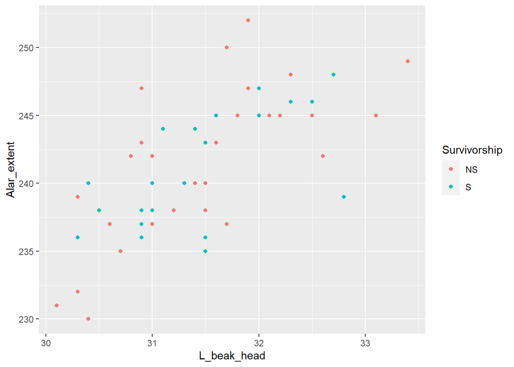

```r
ggplot(sparrows, aes(x=L_beak_head,y=Alar_extent))+geom_point(aes(color=Survivorship))
```

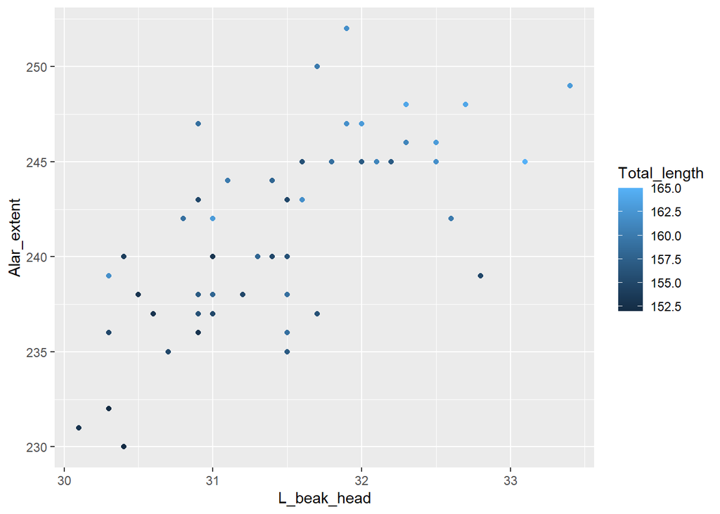

```r
ggplot(sparrows, aes(x=L_beak_head,y=Alar_extent))+geom_point(aes(color=Total_length))
```

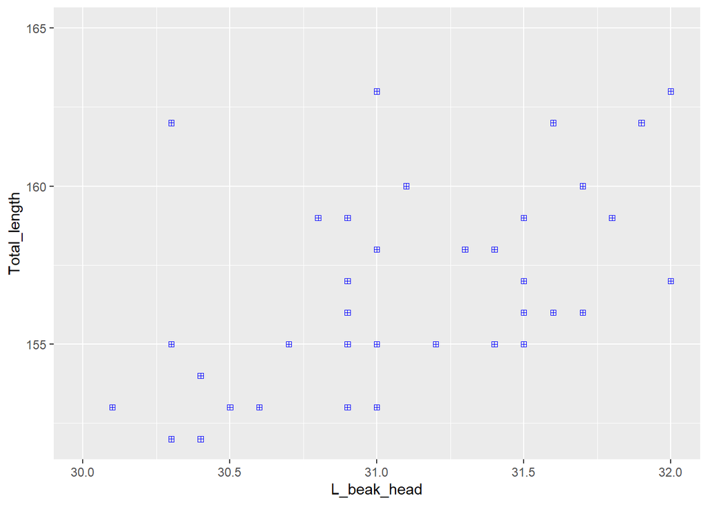

```r
ggplot(sparrows, aes(x=L_beak_head,y=Total_length)) + xlim(30,32) + geom_point(colour="blue",pch=12)
```

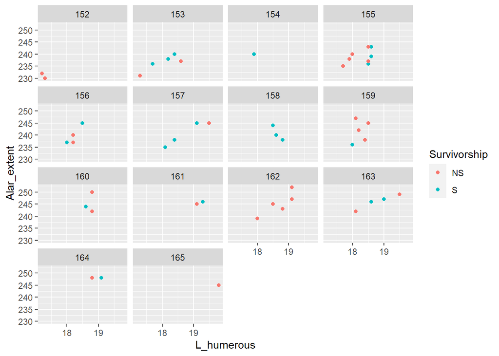

```r
ggplot(sparrows, aes(x=L_humerous,y=Alar_extent)) + facet_wrap(~Total_length) + geom_point(aes(color=Survivorship))
```

- Inference : We can see that in most of the plots that the outliers didn’t survive and the survivors are converging towards the centre.

# Histogram

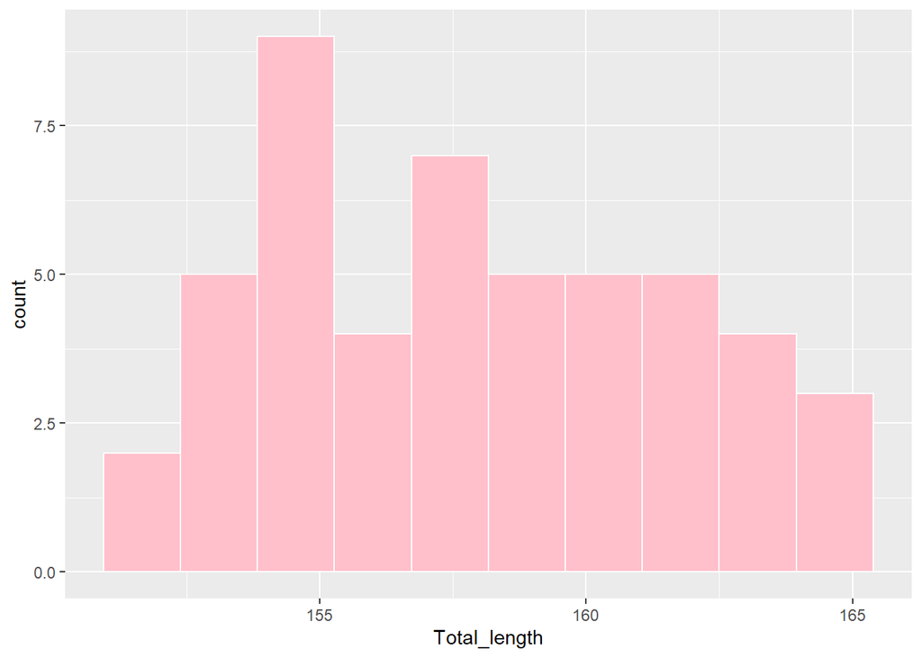

```r
ggplot(sparrows, aes(Total_length))+geom_histogram(fill='pink', color='white',bins=10)
```

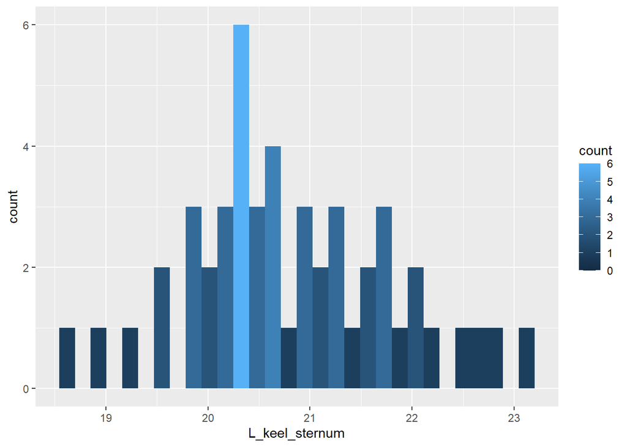

```r
ggplot(sparrows, aes(L_keel_sternum))+geom_histogram(aes(fill=after_stat(count)))
```

# Bar chart

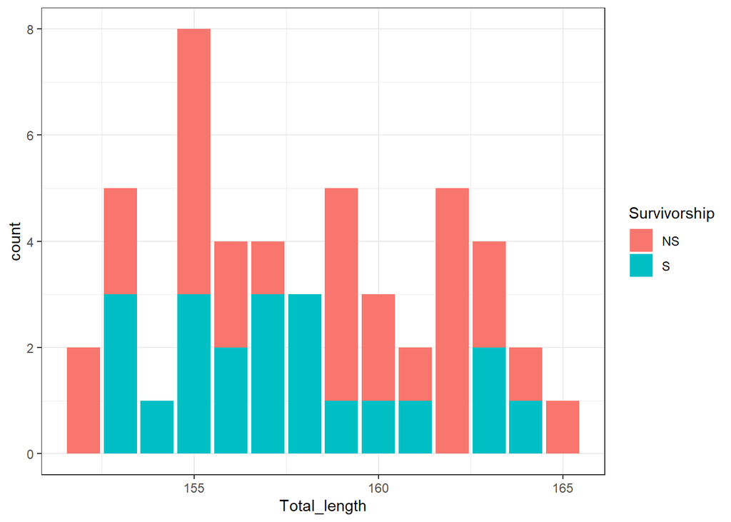

```r
ggplot(sparrows, aes(x=Total_length, fill=Survivorship)) + geom_bar()+theme_bw()
```

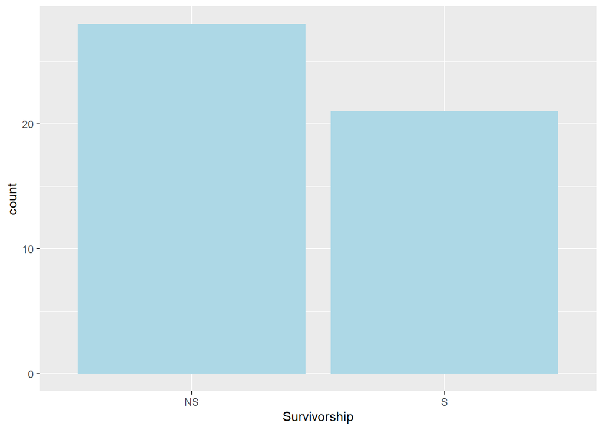

```r
ggplot(sparrows, aes(Survivorship))+ geom_bar(position="stack", fill='lightblue')
```

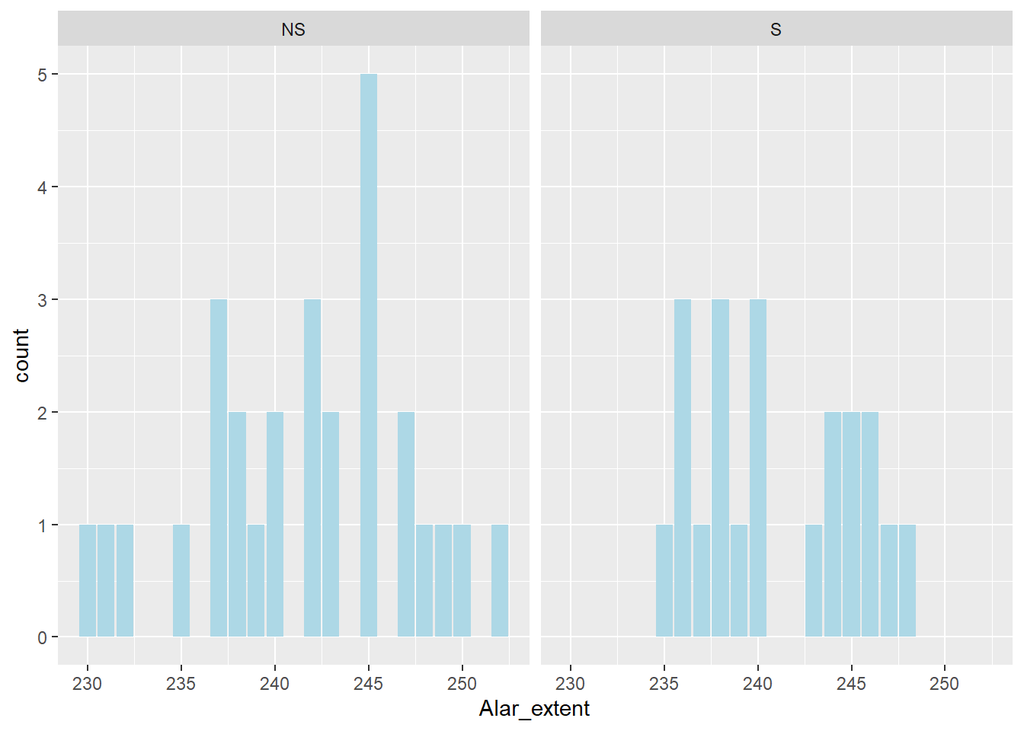

```r
ggplot(sparrows, aes(Alar_extent)) + facet_grid(.~Survivorship) + geom_bar(position="dodge",fill='lightblue')
```

- Inference : We can see that in most of the plots that the outliers didn’t survive and the survivors are converging towards the centre.

# Regression

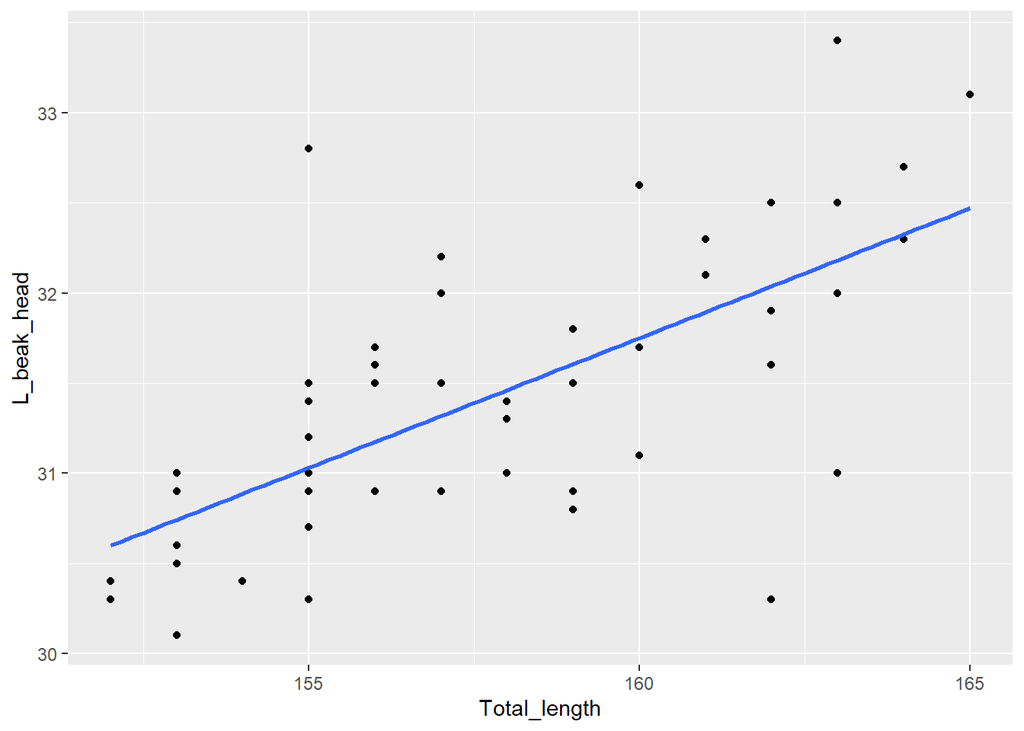

```r
ggplot(sparrows, aes(x=Total_length,y=L_beak_head))+geom_point()+ geom_smooth(method=lm,se= FALSE)
```

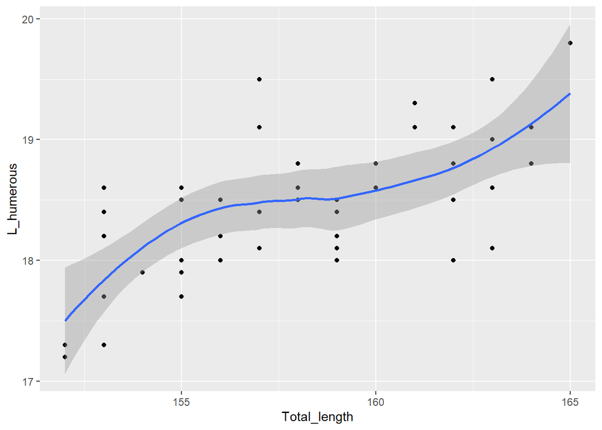

```r
ggplot(sparrows, aes(x=Total_length,y=L_humerous)) + geom_point() + stat_smooth()
```

# Violin plot

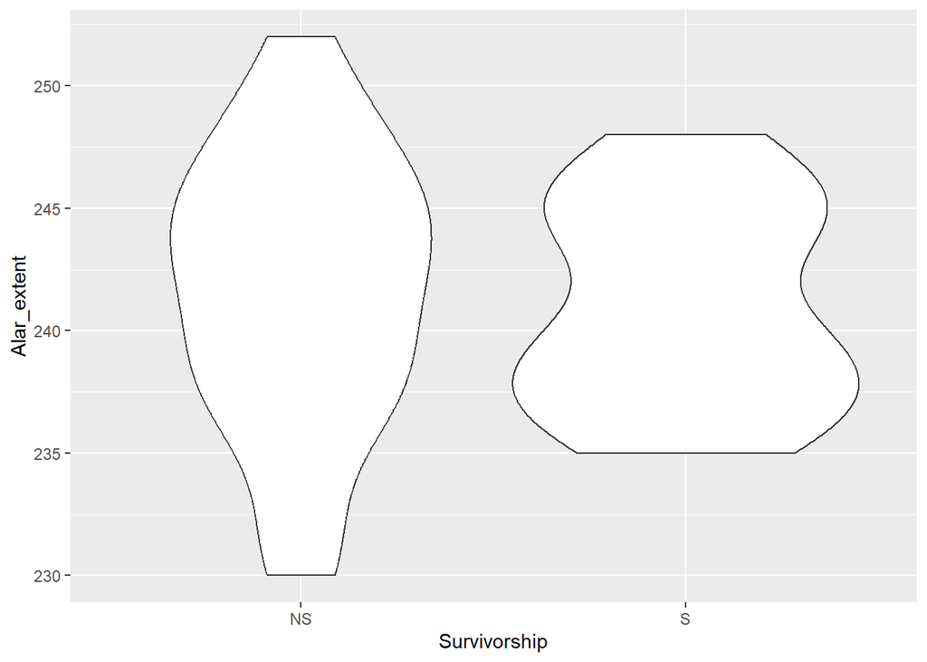

```r
ggplot(sparrows, aes(x=Survivorship,y=Alar_extent)) + geom_violin()
```

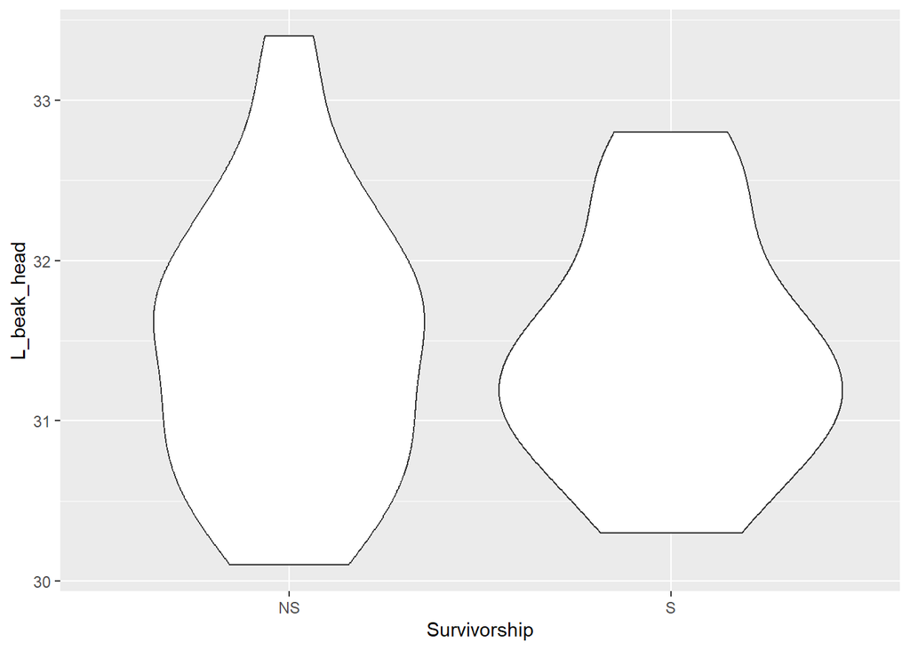

```r
ggplot(sparrows, aes(x=Survivorship,y=L_beak_head)) + geom_violin()
```

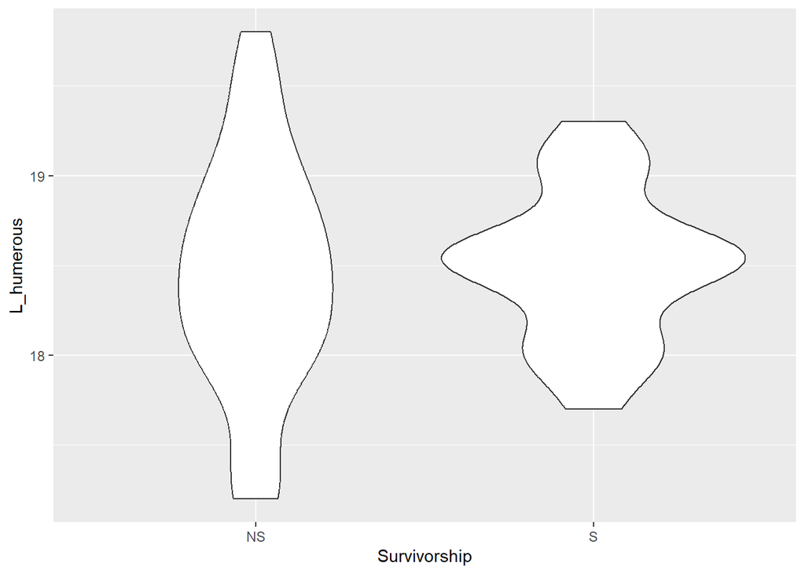

```r
ggplot(sparrows, aes(x=Survivorship,y=L_humerous)) + geom_violin()
```

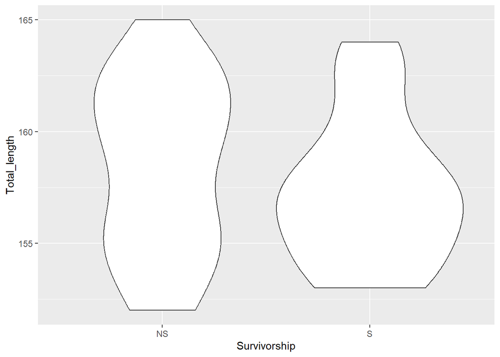

```r
ggplot(sparrows, aes(x=Survivorship,y=Total_length)) + geom_violin()
```

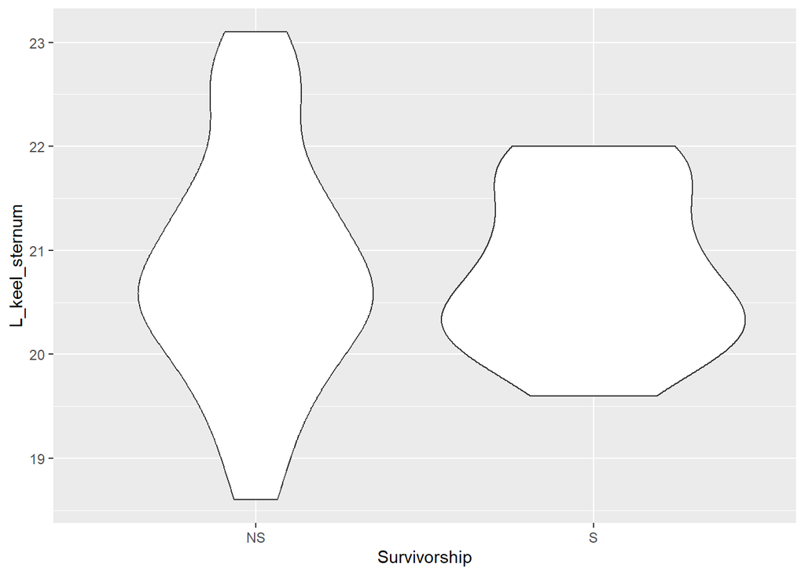

```r
ggplot(sparrows, aes(x=Survivorship,y=L_keel_sternum)) + geom_violin()
```

- Inference : We can see that in most of the plots that the outliers didn’t survive and the survivors are converging towards the centre.

# box plot

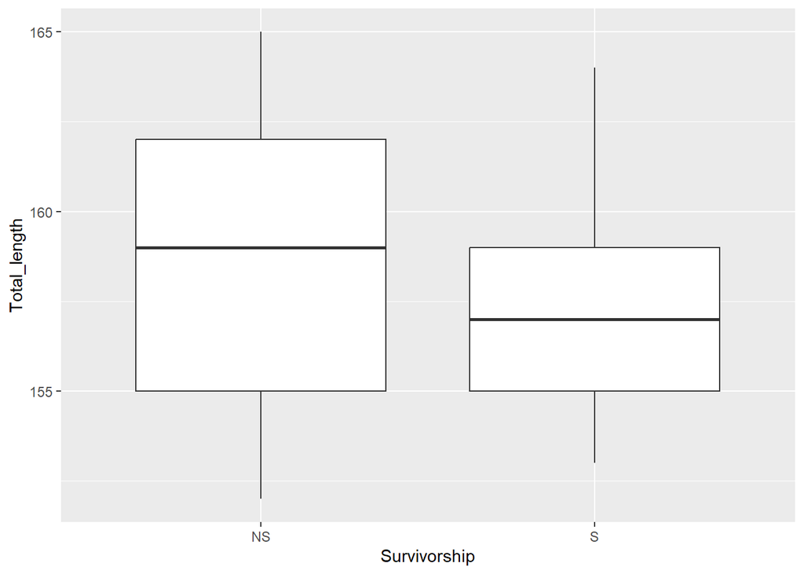

```r
ggplot(sparrows, aes(x=Survivorship,y=Total_length)) + geom_boxplot()
```

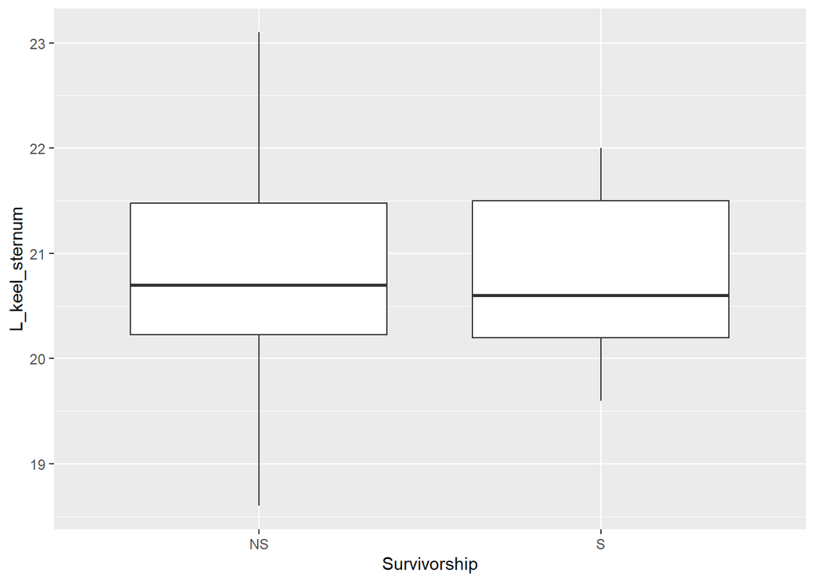

```r
ggplot(sparrows, aes(x=L_keel_sternum,y=Survivorship)) + geom_boxplot() + coord_flip()
```

- Inference : We can see that in most of the plots that the outliers didn’t survive and the survivors are converging towards the centre.

# density plot and ggridges

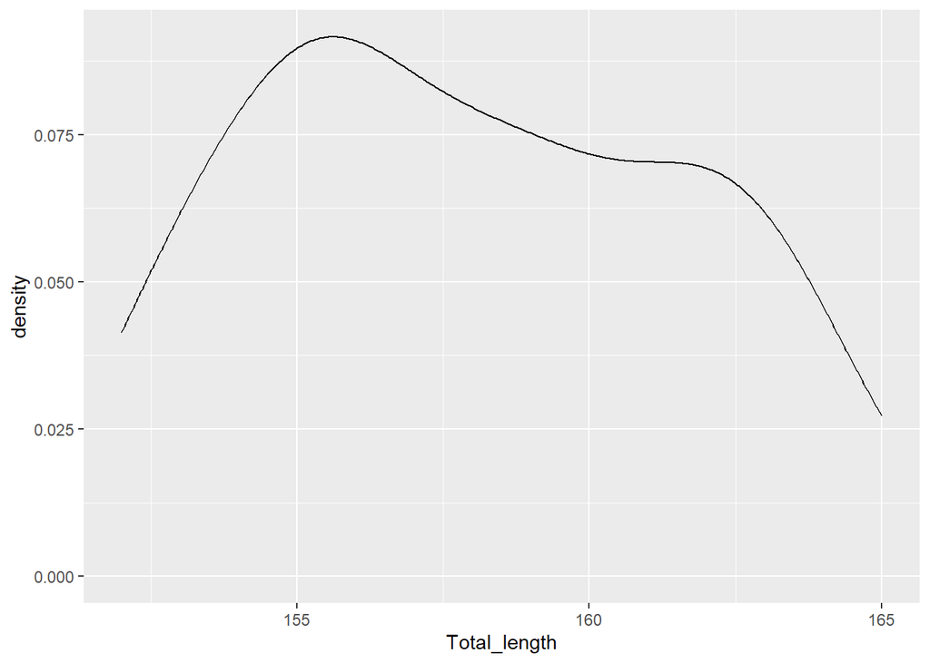

```r
ggplot(sparrows, aes(x=Total_length)) + geom_density()
```

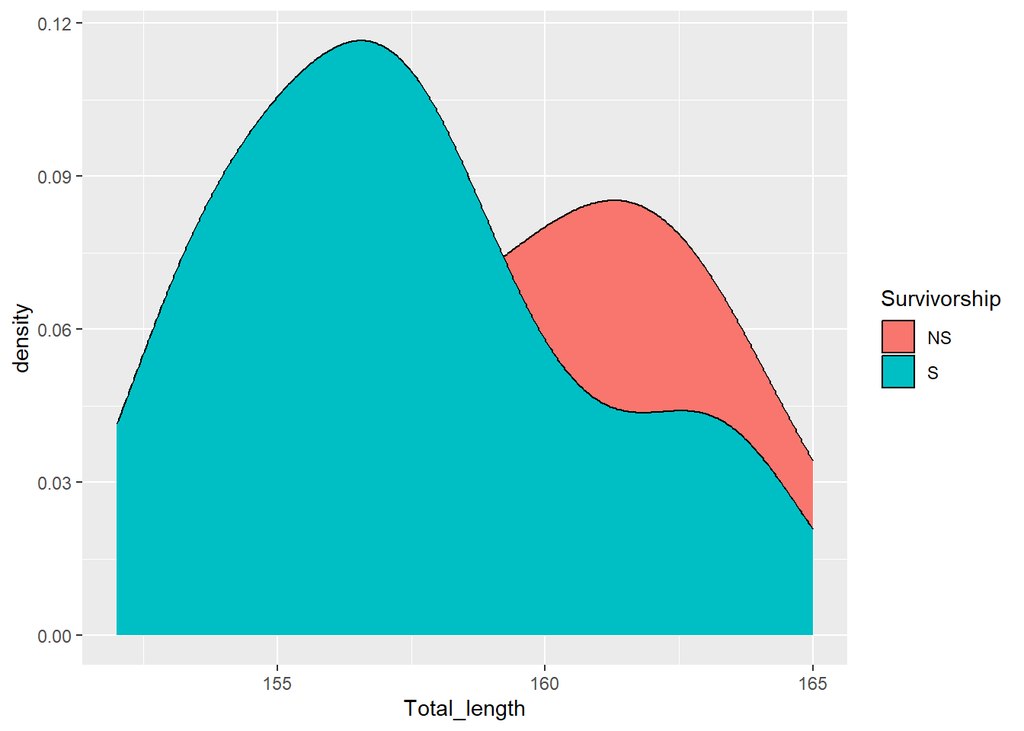

```r
ggplot(sparrows, aes(x=Total_length, fill=Survivorship)) + geom_density()
```

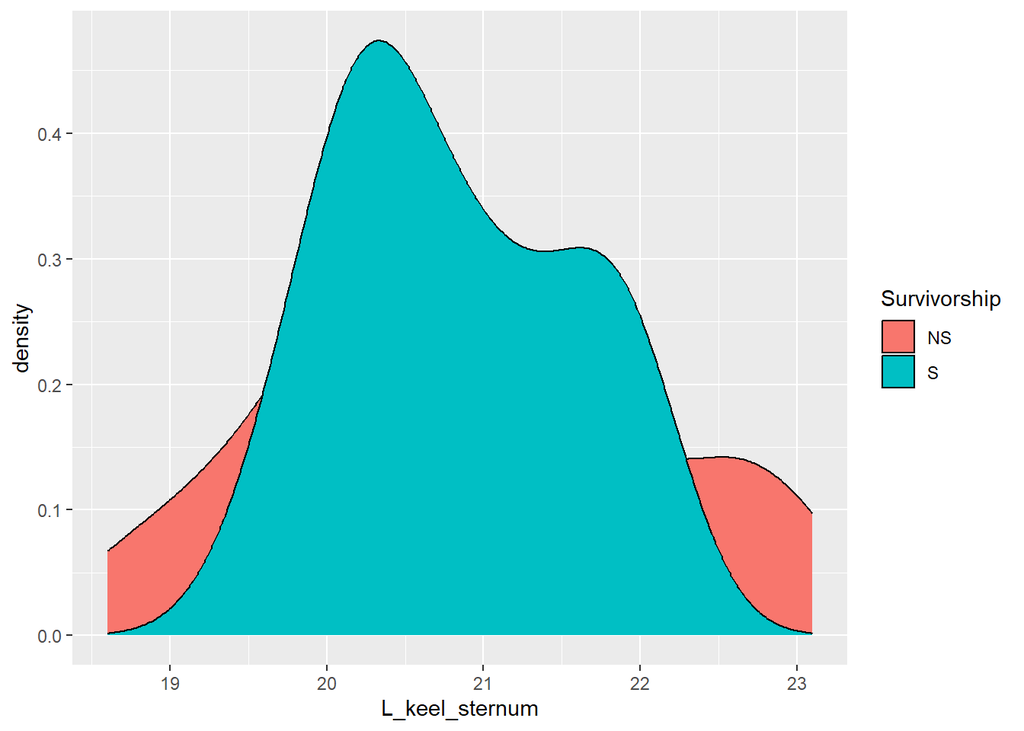

```r
ggplot(sparrows, aes(x=L_keel_sternum, fill=Survivorship)) + geom_density()
```

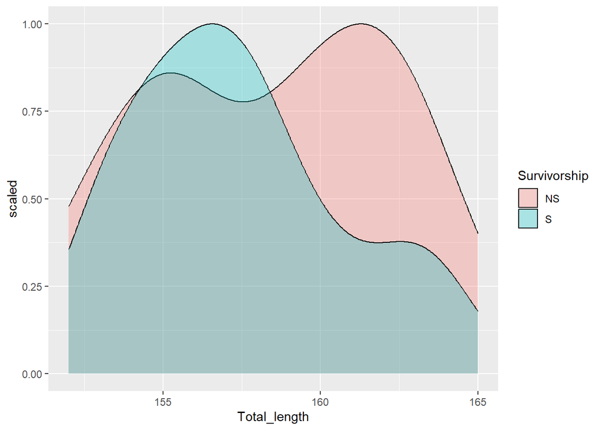

```r
ggplot(sparrows, aes(x=Total_length, fill=Survivorship)) + geom_density(alpha=0.3, aes(y=after_stat(scaled)))
```

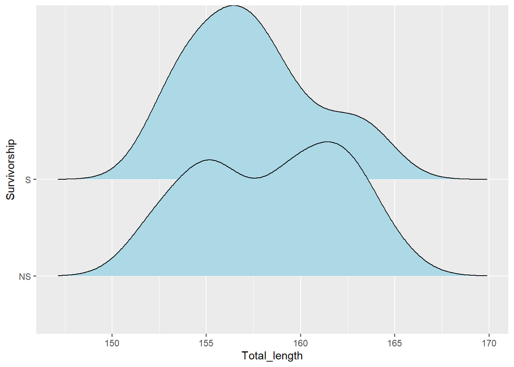

```r
ggplot(sparrows, aes(x=Total_length, y=Survivorship)) + geom_density_ridges(color='black',fill='lightblue')
```

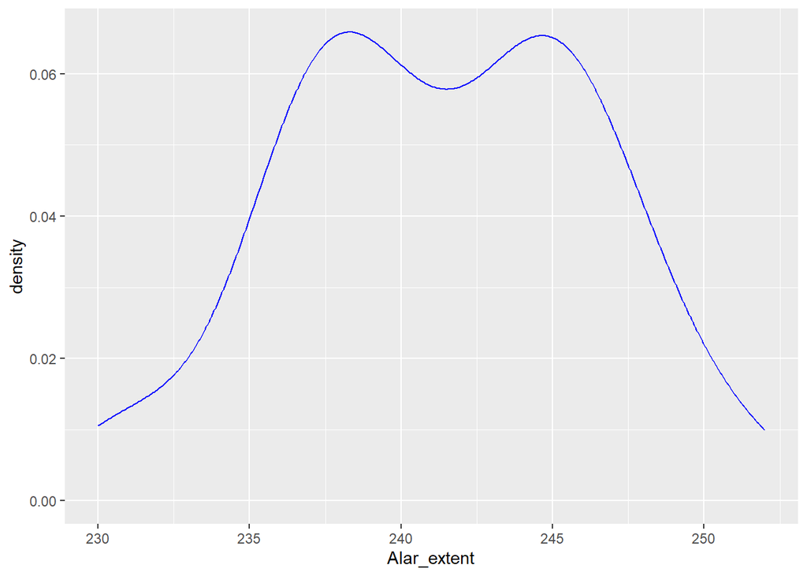

```r
ggplot(sparrows, aes(x=Alar_extent)) + geom_density(color='blue')
```

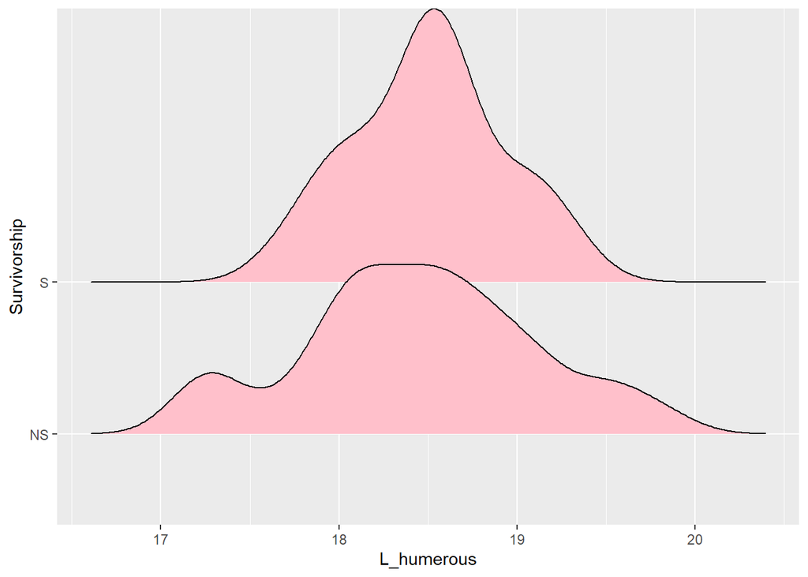

```r
ggplot(sparrows, aes(x=L_humerous, y=Survivorship)) + geom_density_ridges(color='black',fill='pink')
```

- Inference : We can see that in most of the plots that the outliers didn’t survive and the survivors are converging towards the centre.

# hexbin

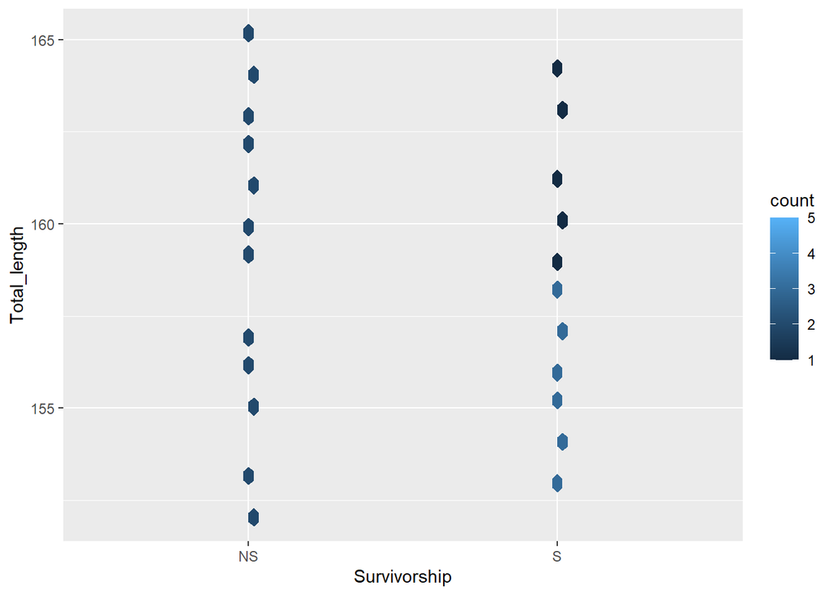

```r
ggplot(sparrows, aes(x=Survivorship, y=Total_length)) + geom_hex()
```

- Inference : We can see that in most of the plots that the outliers didn’t survive and the survivors are converging towards the centre.

# with ggthemes (see also ggsci, ggthemr)

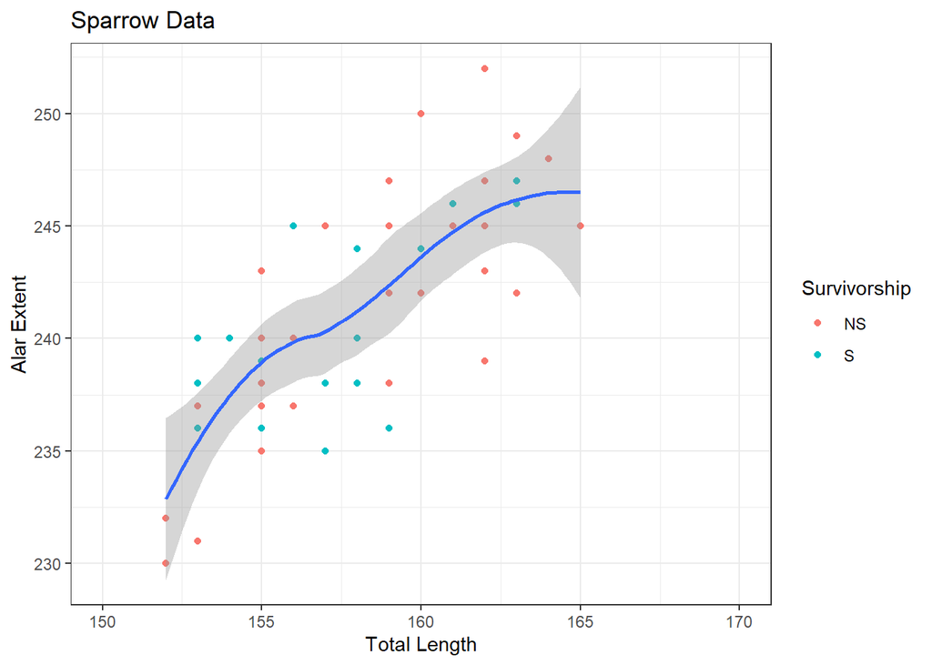

```r
lastplot <- ggplot(sparrows, aes(x=Total_length, y=Alar_extent)) + xlim(150,170) + geom_point(aes(color=Survivorship)) + stat_smooth() +
  labs(x="Total Length", y="Alar Extent", title="Sparrow Data")
lastplot + theme_bw()
```

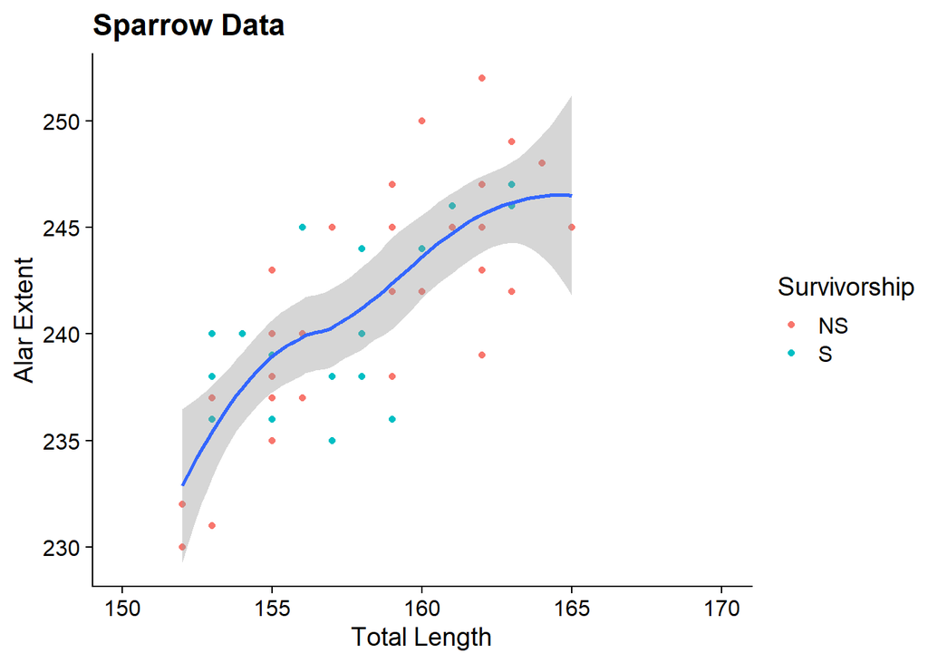

```r
lastplot + theme_cowplot()
```

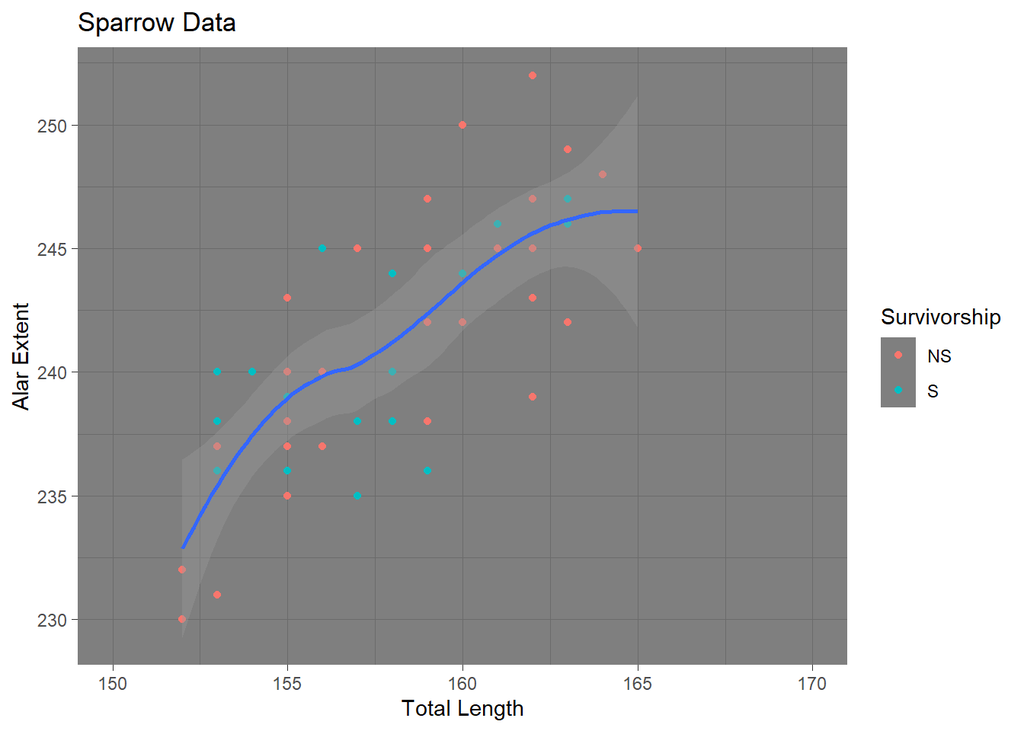

```r
lastplot + theme_dark()
```